# Mapping eQTLs answers

Annique Claringbould

04 October, 2022

## Simple eQTL mapping

In this tutorial, you will identify expression quantitative loci (eQTLs). You will be provided with a list of single nucleotide polymorphisms (SNPs).

Let’s start by cleaning our R environment and installing the necessary package: **MatrixEQTL**.

```r
#rm(list = ls())
#install.packages('MatrixEQTL')
library(MatrixEQTL)
```

The package was developed by Andrey A. Shabalin, more information can be found here: http://www.bios.unc.edu/research/genomic_software/Matrix_eQTL/

**Q1. Find out from the documentation on this package which models we can choose. What are the main differences between the models?**

```
## From documentation:
## * linear - assuming the genotype only has an additive effect on expression
## * ANOVA - allows genotype to have both additive and dominant effect
## * linear cross - testing interaction between genotype and the last covariate
```

We start by setting the base directory, which should be the directory where you store the files from this tutorial: the genotypes, gene expression, SNP locations, and gene locations.

```r
base.dir ='/Users/claringb/Documents/Teaching/Enhpathy/eQTL_mapping/'
```

Then we set the model to linear:

```r
useModel = modelLINEAR
```

Set the file locations, so running the model becomes easy.

```r
# Genotype file names
SNP_file_name = paste(base.dir, "input/genotypes.txt", sep="");
snps_location_file_name = paste(base.dir, "input/snp_locations.txt", sep="");

# Gene expression file names
expression_file_name = paste(base.dir, "input/geuvadis_normalised_gene_expression.txt", sep="");
gene_location_file_name = paste(base.dir, "input/gene_locations.txt", sep="");

# Output file name
output_file_name = paste0(base.dir, "output/results_cis_eQTLs");
```

Next, we need to decide on the p-value threshold. Only the associations that are significant at this level will be saved in your output file. We often use a p-value threshold of 5 * 10^-8 to indicate if a test is significant at the genome wide level. However, here we choose a slightly less stringent threshold, so you can also have a look at less significant effects.

```r
pvOutputThreshold = 5e-7
```

Let’s load the genotype data in. For this first analysis, we do not need the SNP and gene locations yet. MatrixEQTL comes with a specific way to load in large datasets. We only use a limited list of SNPs, so it is not particularly useful here.

```r
snps = SlicedData$new();
snps$fileDelimiter = "\t";      # the TAB character
snps$fileOmitCharacters = "NA"; # denote missing values;
snps$fileSkipRows = 1;          # one row of column labels
snps$fileSkipColumns = 1;       # one column of row labels
snps$fileSliceSize = 2000;      # read file in slices of 2,000 rows
snps$LoadFile(SNP_file_name)
```

```
## Rows read: 134 done.
```

**Q2. For how many SNPs did you just load the genotypes? And for how many people?**  
Hint: Individual names are coded here to start with ‘ERR’, and genetic variants are identified by their reference SNP (rs) number.

```r
dim(snps)[1]
dim(snps)[2]
```

```
## Answer to Q2:
##  There were  134  SNPs,
##  and  373  people
```

We will now load the expression data. As there are many genes in the matrix, the ‘slicing’ of the data will become useful here.

```r
gene = SlicedData$new();
gene$fileDelimiter = "\t";      # the TAB character
gene$fileOmitCharacters = "NA"; # denote missing values;
gene$fileSkipRows = 1;          # one row of column labels
gene$fileSkipColumns = 1;       # one column of row labels
gene$fileSliceSize = 2000;      # read file in slices of 2,000 rows
gene$LoadFile(expression_file_name)
```

**Q3. For how many genes did you just load the expression values? And for how many people? Are there more samples in the genotype or in the expression dataset?**

```r
dim(gene)[1]
dim(gene)[2]
```

```
## Answer to Q3:
##  There were  9577  genes,
##  and  373  people
```

```
## There is an equal number of individuals with gene expression and genotypes
```

We will now run an eQTL mapping analysis for the first time. By naming this model ‘model1’, and giving other models different names, you can save results with different parameters. Do not forget to also change the output_file_name if you want to save the results.

```r
model1 = Matrix_eQTL_engine(
  snps = snps,
  gene = gene,
  output_file_name = output_file_name,
  pvOutputThreshold = pvOutputThreshold,
  useModel = useModel,
  verbose = TRUE,
  pvalue.hist = 100,
  min.pv.by.genesnp = FALSE,
  noFDRsaveMemory = FALSE)
```

**Q4. How many eQTLs do you find?**  
Hint: you can find the answer within the `model1` object using `model1$all`

```r
dim(model1$all$eqtls)[1]
```

```
## Answer to Q4:
##  There were 53 eQTLs
```

The object `model1` contains more interesting information about the eQTL analysis. The input parameters, how long the analysis took, and the eQTL results are all saved here. You can use this info to display the results:

```r
model1$time.in.sec
show(model1$all$eqtls)
```

```
## 0.838
```

```
##           snps            gene  statistic        pvalue           FDR
## 1    rs1799987 ENSG00000160791  35.252713 1.731350e-120 2.221873e-114
## 2  rs111421016 ENSG00000229391 -21.684993  6.147025e-68  3.944294e-62
## 3  rs115013759 ENSG00000229391 -21.400160  9.442548e-67  4.039264e-61
## 4    rs2058660 ENSG00000115602 -16.678036  5.338848e-47  1.712860e-41
## 5  rs114240154 ENSG00000237541 -14.832137  2.089480e-39  5.362936e-34
## 6     rs660895 ENSG00000237541 -13.484978  5.272965e-34  1.127815e-28
## 7  rs115013759 ENSG00000237541 -12.986276  4.786785e-32  8.775668e-27
## 8     rs532098 ENSG00000237541 -12.705480  5.898522e-31  9.462100e-26
## 9  rs111421016 ENSG00000237541 -12.507550  3.420543e-30  4.877382e-25
## 10   rs9273493 ENSG00000179344  12.359268  1.267258e-29  1.626295e-24
## 11   rs4320356 ENSG00000026950  11.980438  3.493573e-28  4.075786e-23
## 12 rs116474664 ENSG00000237541 -11.664157  5.383282e-27  5.757052e-22
## 13 rs115013759 ENSG00000232629 -11.437227  3.753693e-26  3.705524e-21
## 14 rs114240154 ENSG00000232629 -11.362550  7.084844e-26  6.494363e-21
```

[output cut: 93 more lines]

**Q5. How many tests were performed in total?**

```r
model1$all$ntests
```

```
## Answer to Q5:
##  The number of tests is 1283318
```

**Q6. What percentage of those is significant, according to the threshold that we set earlier?**  
Hint: use `model1$neqtls` and the answer from **Q5**

```r
sign <- round((model1$all$neqtls/model1$all$ntests)*100, digits = 4)
```

```
## Answer to Q6:
##  The percentage of significance is 0.0041 %
```

In the results that we have created now, the associations between all SNPs and all genes are tested. However, you have learned that there is a difference between *cis*-eQTLs and *trans*-eQTLs. Therefore, we will now continue to run the model separately SNPs that lie close to the genes, and those that are further away from the gene.

## *Cis*- and *trans*-eQTL mapping

The first thing to do, again, is to set the names of the output files. This time you will get two separate files.

```r
output_file_name_cis = paste0(base.dir,"output/cis_eQTLs_CeD_out.txt")
output_file_name_trans = paste0(base.dir,"output/trans_eQTLs_CeD_out.txt")
```

Next, we will set a P-value threshold for both the *cis*-eQTL and *trans*-eQTL associations. Let’s start with **5e-2** and **5e-5**, respectively.

```r
# Only associations significant at this level will be saved
pvOutputThreshold_cis = 5e-2
pvOutputThreshold_trans = 5e-5
```

Read in the files with SNP and gene positions.

```r
snpspos = read.table(snps_location_file_name, header = TRUE, stringsAsFactors = FALSE)
genepos = read.table(gene_location_file_name, header = TRUE, stringsAsFactors = FALSE)
```

**Q7. What information is provided for each SNP and each gene in these files? How many SNPs and genes are available in these files?**

```r
dim(snpspos)[1]
dim(genepos)[1]
```

```
## Answer to Q7:
##  There is information about the chromosomal location of each SNP and gene
##  There is information on 134 SNPs and 53934 genes
```

Last, we need to set the maximum distance between a SNP and the gene, that we would still call a *cis-*eQTL. The unit of measurement is basepairs. Set the distance to 1Mb.

```r
cisDist = 1000000
```

Since we still have the data loaded from the first run, the next step is to simply run the model, this time with output for cis- and trans-eQTLs separately.

```r
output_file_name_cis = paste0(base.dir,"output/results_cis_eQTLs_only");
output_file_name_trans = paste0(base.dir,"output/results_trans_eQTLs_only")
```

```r
model2 = Matrix_eQTL_main(
  snps = snps,
  gene = gene,
  output_file_name     = output_file_name_trans,
  pvOutputThreshold     = pvOutputThreshold_trans,
  useModel = useModel,
  verbose = TRUE,
  output_file_name.cis = output_file_name_cis,
  pvOutputThreshold.cis = pvOutputThreshold_cis,
  snpspos = snpspos,
  genepos = genepos,
  cisDist = cisDist,
  pvalue.hist = 100,
  min.pv.by.genesnp = FALSE,
  noFDRsaveMemory = FALSE)
```

**Q8. How many *cis* and *trans*-eQTLs did you find?**

```r
model2$cis$neqtls
model2$trans$neqtls
```

```
## Answer to Q8:
##  There are 209 cis-eQTLS and 118 trans-eQTLs
```

**Q9. How many *cis* and *trans* tests were performed? Where does this difference in scale come from?**

```r
model2$cis$ntests
model2$trans$ntests
```

```
## Answer to Q9:
##  There are 1951 cis tests and 1281367 trans tests
```

```
## The difference is because in cis-eQTLs only a limited number of SNP-gene combinations is tested, as defined by genes that are close to the SNPs.
```

**Q10. What percentage of *cis* and *trans* tests are significant eQTLs?**

```r
cis <- round((model2$cis$neqtls/model2$cis$ntests)*100, digits = 4)
trans <- round((model2$trans$neqtls/model2$trans$ntests)*100, digits = 4)
```

```
## Answer to Q10:
##  The percentage of significant cis-eQTLs is  10.7125 % and the percentage of trans-eQTLs is 0.0092 %
```

**Q11. How many unique SNPs are part of a *cis*eQTL? and of a *trans*-eQTL?**  
Hint: use the functions `length()` and `unique()` for this question

```r
unique(length(model2$cis$eqtls$snps))
unique(length(model2$trans$eqtls$snps))
```

[output not shown]

(  
Run another model, where you look at both *cis*- and *trans*-eQTLs, but this time, use p-values of **5e-3** and **5e-6** respectively, and set the distance to consider a cis-eQTL ‘local’ to 2Mb.)

```r
cisDist = 2000000

output_file_name_cis = paste0(base.dir,"output/results_cis_eQTLs_only_newp")
output_file_name_trans = paste0(base.dir,"output/results_trans_eQTLs_only_newp")

pvOutputThreshold_cis = 5e-3
pvOutputThreshold_trans = 5e-6

model3 = Matrix_eQTL_main(
  snps = snps,
  gene = gene,
  output_file_name     = output_file_name_trans,
  pvOutputThreshold     = pvOutputThreshold_trans,
  useModel = useModel,
  verbose = TRUE,
  output_file_name.cis = output_file_name_cis,
  pvOutputThreshold.cis = pvOutputThreshold_cis,
  snpspos = snpspos,
  genepos = genepos,
  cisDist = cisDist,
  pvalue.hist = 100,
  min.pv.by.genesnp = FALSE,
  noFDRsaveMemory = FALSE)
```

```
## Matching data files and location files
```

```
## 9029 of 9577 genes matched
```

```
## 134 of 134 SNPs matched
```

```
## Task finished in 0.011 seconds
```

```
## Reordering genes
```

```
## Task finished in 0.284 seconds
```

```
## Processing covariates
```

```
## Task finished in 0.001 seconds
```

```
## Processing gene expression data (imputation, residualization)
```

```
## Task finished in 0.132 seconds
```

```
## Creating output file(s)
```

```
## Task finished in 0.011 seconds
```

```
## Performing eQTL analysis
```

```
## 19.99% done, 10 cis-eQTLs, 1 trans-eQTLs
```

```
## 39.99% done, 106 cis-eQTLs, 12 trans-eQTLs
```

```
## 60.00% done, 107 cis-eQTLs, 17 trans-eQTLs
```

```
## 80.00% done, 122 cis-eQTLs, 23 trans-eQTLs
```

[output not shown]

```
## Task finished in 0.638 seconds
```

## Plotting

MatrixEQTL has some in-built plotting functions. You can see the plots by running the following:

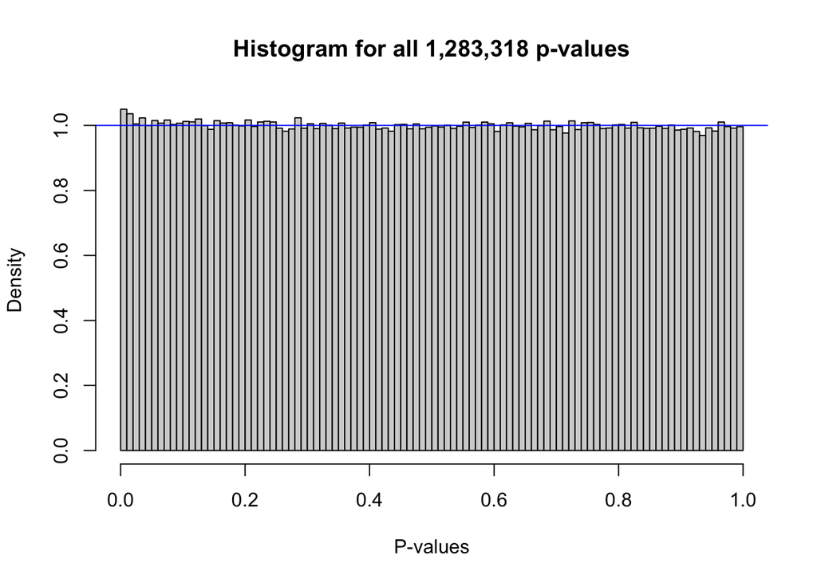

```r
plot(model1)
```

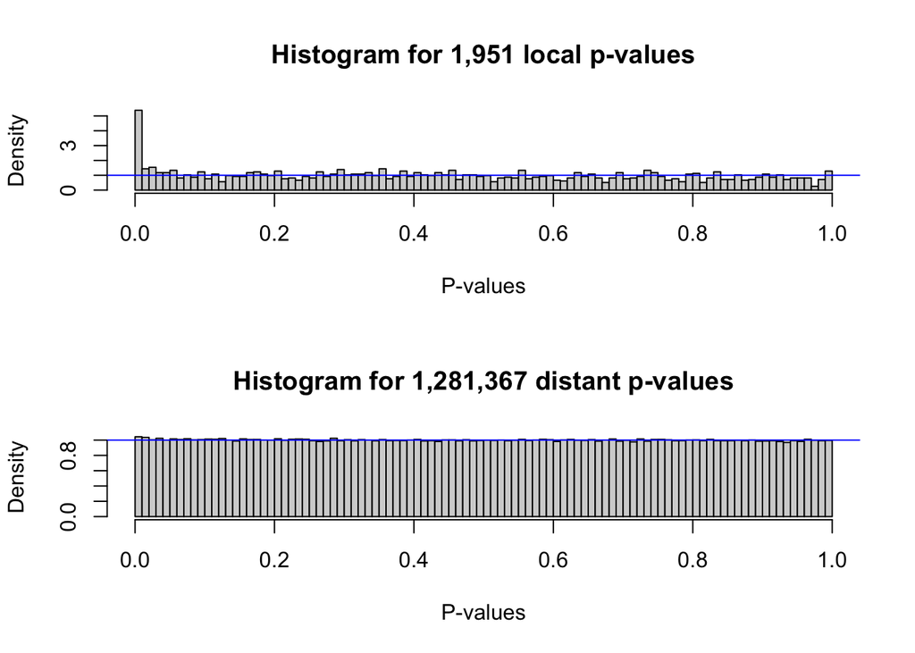

```r
plot(model2)
```

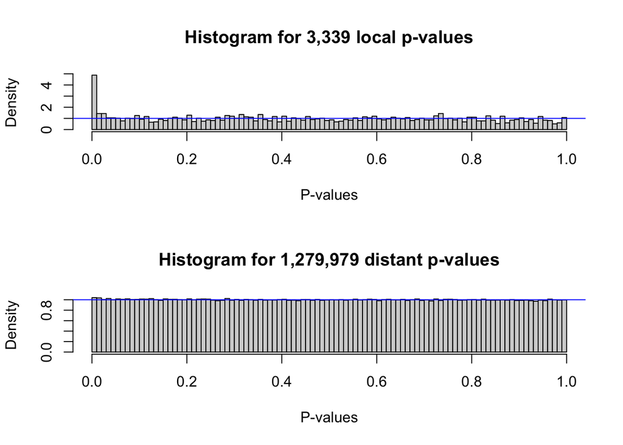

```r
plot(model3)
```

**Q12. What is the type of plot you get out?**

```
## Answer to Q12:
##  A histogram of the p-values generated for both the cis- and trans-eQTLs
```

Run the same model again, with this change:

```r
  pvalue.hist = "qqplot"
```

```r
cisDist = 2000000

pvOutputThreshold_cis = 5e-3
pvOutputThreshold_tra = 5e-6

model5 = Matrix_eQTL_main(
  snps = snps,
  gene = gene,
  output_file_name     = output_file_name_trans,
  pvOutputThreshold     = pvOutputThreshold_trans,
  useModel = useModel,
  verbose = TRUE,
  output_file_name.cis = output_file_name_cis,
  pvOutputThreshold.cis = pvOutputThreshold_cis,
  snpspos = snpspos,
  genepos = genepos,
  cisDist = cisDist,
  pvalue.hist = "qqplot",
  min.pv.by.genesnp = FALSE,
  noFDRsaveMemory = FALSE)
```

**Q13. What plot do you get now? What does this tell you about the p-value cut-off we chose?**

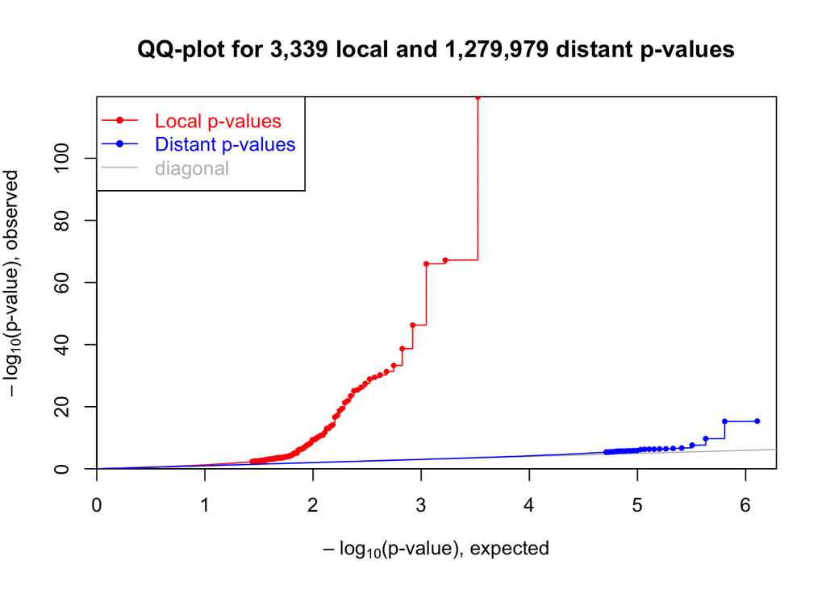

```
## Answer to Q13:
##  A QQ-plot. If you look at where the pattern starts deviating from the expected line, it looks like the threshold for significant trans-eQTLs seems fair for cis-eQTLs and trans-eQTLs.
```

```r
plot(model5)
```

We will now make some eQTL boxplots, where we show the actual expression of a gene of interest, separated by genotypes. For this example, we will use the top detected eQTL:  
**rs1799987 - ENSG00000160791**

```r
gene2 <- as.matrix(gene)
gene2 <- as.data.frame(gene2[row.names(gene2) == "ENSG00000160791",])
snps2 <- as.matrix(snps)
snps2 <- as.data.frame(snps2[row.names(snps2) == "rs1799987",])
eqtl <- merge(snps2,gene2,by="row.names")
colnames(eqtl) <- c("sample", "genotype", "expression")
eqtl$genotype <- as.factor(eqtl$genotype)
```

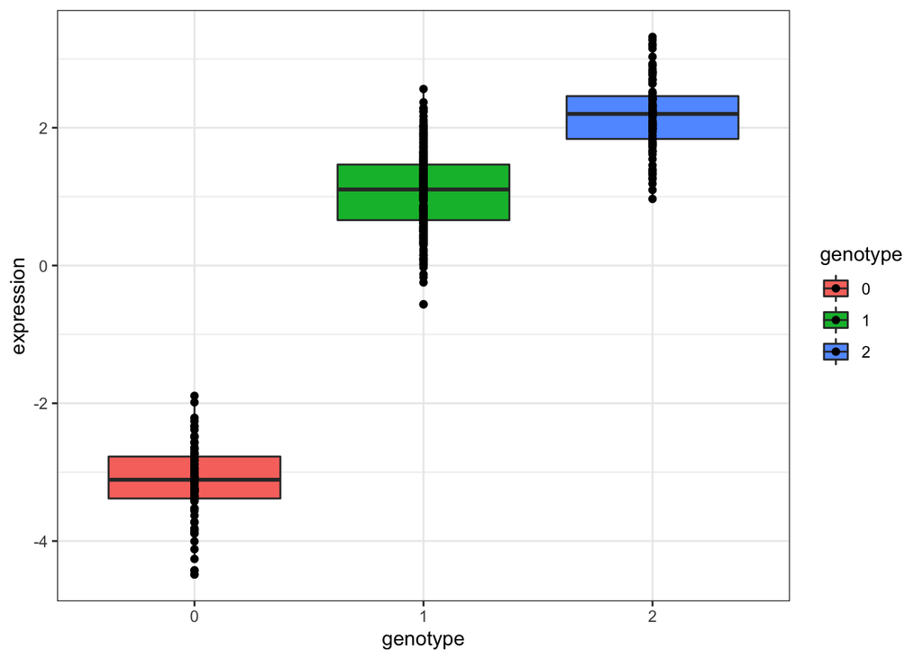

```r
library(ggplot2)
ggplot(data=eqtl, aes(x=genotype,y=expression, fill = genotype)) +
  geom_boxplot() +
  geom_point() +
  theme_bw()
```

**Q14. Which genotype causes this gene to be upregulated?**  
Hint: genotype 0 here stands for ‘GG’. Using online sources like https://www.ncbi.nlm.nih.gov/projects/SNP/, you should be able to figure out what the other allele for this SNP is.

```
## Answer to Q14:
##  Genotype 2 (which corresponds to AA).
```

**Q15. Make the same plot for the fourth eQTL: rs2058660 - ENSG00000115602**  
This time add whether this is a *cis*- or *trans*-eQTL in the title.  
Look up the gene name (the ENSG code) and add that to the title as well.  
Hint 1. find SNP location first (see below)  
Hint 2. Find gene location in the same way  
Hint 3. Check positions: is this a local (cis) or distal (trans) effect?  
Hint 4. Add a title by adding this to the command for plotting:

```r
snpspos[snpspos$snpid == "rs2058660",]
```

```
##        snpid  chr       pos
## 23 rs2058660 chr2 103054449
```

```r
genepos[genepos$geneid == "ENSG00000115602",]
```

```
##               geneid  chr      left     right
## 6839 ENSG00000115602 chr2 102927962 102968497
```

```r
gene2 <- as.matrix(gene)
gene2 <- as.data.frame(gene2[row.names(gene2) == "ENSG00000115602",])
snps2 <- as.matrix(snps)
snps2 <- as.data.frame(snps2[row.names(snps2) == "rs2058660",])
eqtl <- merge(snps2,gene2,by="row.names")
colnames(eqtl) <- c("sample", "genotype", "expression")
eqtl$genotype <- as.factor(eqtl$genotype)
```

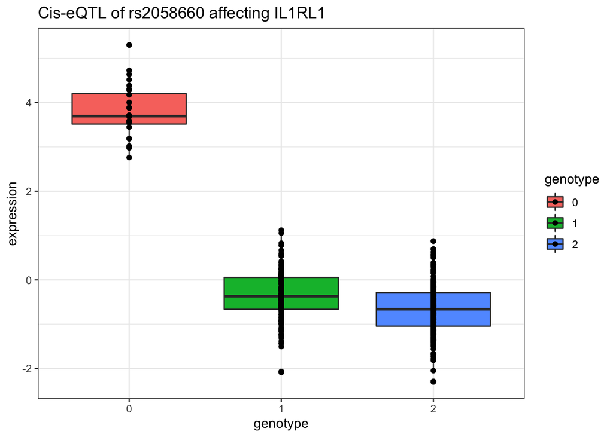

```r
ggplot(data=eqtl, aes(x=genotype,y=expression, fill = genotype)) +
  geom_boxplot() +
  geom_point() +
  theme_bw() +
  ggtitle("Cis-eQTL of rs2058660 affecting IL1RL1")
```

Look rs2058660 up on [GWAS catalog](https://www.ebi.ac.uk/gwas/).

**Q16. What phenotype was this SNP first associated with? What was the risk allele? Is there a known link between the GWAS phenotype and the gene?**

[output not shown]